# ENEC891_final_proj_Moore

Elizabeth Moore

December 9, 2019

## ENEC 891 Final

## Exploration of field temperature manipulation data collected Summer 2019

### Background

I conducted a field experiment at Mason Farm Biological Reserve in the summer of 2019 to investigate the effects of natural and manipulated field temperatures on the growth, development and survival of the Lepidoptera *Manduca sexta* and its hymenopteran parasitoid, *Cotesia congregata*. In laboratory conditions, *C. congregata* has been shown to have lower thermal tolerance and greater thermal sensitivity than its caterpillar host. The goal of this experiment was to see if similar trends exist in field conditions.

### Experimental design:

Two field plots were established (12m x 10m each) in the experimental area of Mason Farm. Each plot consisted of 6 rows of 10 tobacco plants, for a total of 120 plants across both plots. Plants were grown in the greenhouse at UNC and transferred to Mason Farm between 7-8 weeks after germination. Plants in plot 1 were planted in the ground 12-16 days after being transferred to the field site, and plot 2 plants 26-31 days after. The field plots were covered in weed barrier before planting. Half of the area was covered with black weed barrier, to increase the temperature by collecting radiative solar energy and releasing it back onto the plants. The other half was covered with grey weed barrier to serve as a control. Black and grey weed barrier treatments were set up in a block design, and the order of the blocks was reversed between plot 1 and plot 2 (see image below).

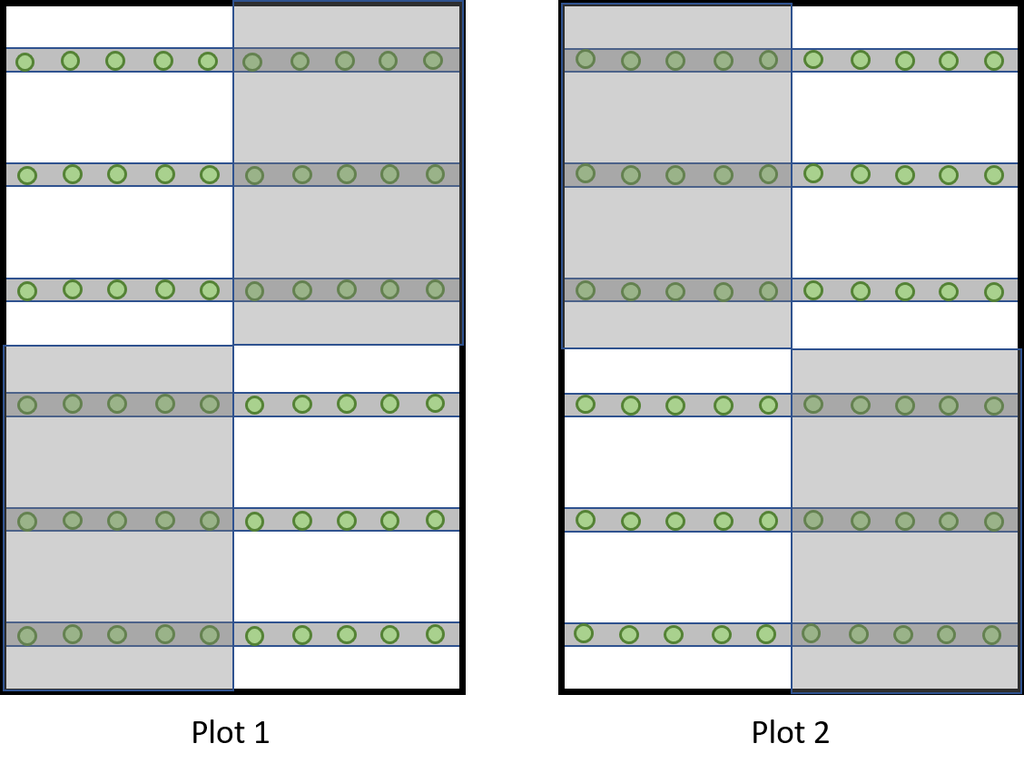

Fig 1. Plot lay out

Temperature in the field was measured and recorded with a datalogger, using thermoconductive caterpillars models with inserted thermocouples. 20 models were placed in plot 1 for the duration of the experiment. 10 models were placed on plants in the black weed barrier treatment, and 10 on plants in the grey. Models were placed on the underside of leaves along the midvein, where *M. sexta* caterpillars often rest when not feeding. Models were placed at varying heights (high, middle or low) on the plants.

The experimental design consisted of a 2x2 factorial design, with two parasitization treatments (NP and P) and two weed barrier treatments (black and grey). Caterpillars were reared in the lab at 25+/-10 from hatching to the 3rd instar on fresh tobacco leaves. At the 3rd instar, they were massed and assigned to a parasitization and weed barrier treatment, and assigned to a specific plant in one of the plots. Each plant was assigned two caterpillars, in either a NP, P or P, P combination. On day 0 of the 3rd instar, caterpillars in the P treatment were parasitized. All 3rd instars were returned to containers with fresh tobacco leaves at 25+/-10 until day 1 of the 3rd instar, when they were transported to the field and placed on their assigned plant.

Daily censes were conducted to monitor caterpillar survival, development, and behavior. Caterpillar presence and location on the plant was recorded each day, including height on plant (high, middle, low), leaf surface (upper or under) and if it was in the sun or shade. If a caterpillar was not found 2 days in a row, it was recorded as dead. Dead caterpillars were replaced if there were enough reared caterpillars in lab at the 3rd instar. Development time was recorded at each molt. Caterpillars were collected off the plants and returned to lab 3-4 days after molt to the 5th instar for the NP treatment, and 4-5 days for the P treatment. Date and mass at wandering were recorded for NP caterpillars. Date at wasp emergence and mass 48 hours after wasp emergence was recorded for the P treatment. Wasp cocoons were removed from the host 48 hours after wasp emergence, and placed at 25+/-10 until adult eclosion. Hosts were frozen for future dissection to determine total parasitoid load. Wasp survival was recorded at emergence, cocoon formation and eclosion. After eclosion, adult wasps were frozen and sexed under a dissecting scope. Males and females were grouped by sex, and weighed en masse. The group mass was divided by the number of individuals to obtain the mean adult wasp mass for each sex for each host.

## Proposed analyses:

### Caterpillar mass and development time

So far, I have analyzed caterpillar mass and development time data using separate linear models, with the change in mass (final mass - initial mass) and age (final age - initial age) as the response variables, and weed barrier treatment, parasitization treatment and plot as fixed effects.

```r
#analyze delta mass and delta age with lm models

dm_mod1 <- lm(dlta_mss ~ treat_heat*obs_treatp*plot_id,
              data=ftm_cl,
              na.action = na.omit)
anova(dm_mod1)
```

```
## Analysis of Variance Table
##
## Response: dlta_mss
##                                Df Sum Sq Mean Sq  F value    Pr(>F)
## treat_heat                      1  0.686   0.686   3.0917  0.080268 .
## obs_treatp                      1 71.911  71.911 324.0765 < 2.2e-16 ***
## plot_id                         1  8.651   8.651  38.9876 2.635e-09 ***
## treat_heat:obs_treatp           1  0.008   0.008   0.0349  0.851949
## treat_heat:plot_id              1  0.204   0.204   0.9207  0.338479
## obs_treatp:plot_id              1  1.837   1.837   8.2782  0.004462 **
## treat_heat:obs_treatp:plot_id   1  0.004   0.004   0.0190  0.890536
## Residuals                     194 43.048   0.222
## ---
## Signif. codes:  0 '***' 0.001 '**' 0.01 '*' 0.05 '.' 0.1 ' ' 1
```

```r
summary(dm_mod1)
```

```
##
## Call:
## lm(formula = dlta_mss ~ treat_heat * obs_treatp * plot_id, data = ftm_cl,
##     na.action = na.omit)
##
## Residuals:
##      Min       1Q   Median       3Q      Max
## -1.84029 -0.24617  0.01962  0.29217  1.07700
##
## Coefficients:
##                                           Estimate Std. Error t value Pr(>|t|)
## (Intercept)                                5.20358    0.09822  52.977  < 2e-16
## treat_heaths                               0.01810    0.15335   0.118   0.9062
## obs_treatpobs_p                           -1.07072    0.13153  -8.141 4.66e-14
## plot_idplot2                              -0.12053    0.15335  -0.786   0.4328
## treat_heaths:obs_treatpobs_p               0.02260    0.19198   0.118   0.9064
## treat_heaths:plot_idplot2                 -0.07345    0.22150  -0.332   0.7406
## obs_treatpobs_p:plot_idplot2              -0.38051    0.19846  -1.917   0.0567
## treat_heaths:obs_treatpobs_p:plot_idplot2 -0.03833    0.27811  -0.138   0.8905
##
## (Intercept)                               ***
## treat_heaths
## obs_treatpobs_p                           ***
## plot_idplot2
## treat_heaths:obs_treatpobs_p
## treat_heaths:plot_idplot2
## obs_treatpobs_p:plot_idplot2              .
## treat_heaths:obs_treatpobs_p:plot_idplot2
## ---
## Signif. codes:  0 '***' 0.001 '**' 0.01 '*' 0.05 '.' 0.1 ' ' 1
##
## Residual standard error: 0.4711 on 194 degrees of freedom
##   (3 observations deleted due to missingness)
## Multiple R-squared:  0.6593, Adjusted R-squared:  0.647
## F-statistic: 53.63 on 7 and 194 DF,  p-value: < 2.2e-16
```

```r
da_mod1 <- lm(dlta_age ~ treat_heat*obs_treatp*plot_id,
              data=ftm_cl,
              na.action = na.omit)
anova(da_mod1)
```

```
## Analysis of Variance Table
##
## Response: dlta_age
##                                Df Sum Sq Mean Sq F value    Pr(>F)
## treat_heat                      1   0.01   0.009  0.0052 0.9428473
## obs_treatp                      1 113.87 113.870 66.1091 4.958e-14 ***
## plot_id                         1  23.30  23.297 13.5252 0.0003047 ***
## treat_heat:obs_treatp           1   0.41   0.407  0.2363 0.6274228
## treat_heat:plot_id              1   0.17   0.170  0.0989 0.7534739
## obs_treatp:plot_id              1   1.81   1.806  1.0483 0.3071657
## treat_heat:obs_treatp:plot_id   1   4.90   4.905  2.8477 0.0931131 .
## Residuals                     194 334.16   1.722
## ---
## Signif. codes:  0 '***' 0.001 '**' 0.01 '*' 0.05 '.' 0.1 ' ' 1
```

```r
summary(da_mod1)
```

```
##
## Call:
## lm(formula = dlta_age ~ treat_heat * obs_treatp * plot_id, data = ftm_cl,
##     na.action = na.omit)
##
## Residuals:
##     Min      1Q  Median      3Q     Max
## -2.6250 -0.6410 -0.0303  0.3590  8.9474
##
## Coefficients:
##                                           Estimate Std. Error t value Pr(>|t|)
## (Intercept)                                11.1739     0.2737  40.832  < 2e-16
## treat_heaths                               -0.5489     0.4272  -1.285   0.2004
## obs_treatpobs_p                             1.5502     0.3664   4.230 3.59e-05
## plot_idplot2                                0.4511     0.4272   1.056   0.2924
## treat_heaths:obs_treatpobs_p                0.4658     0.5349   0.871   0.3849
## treat_heaths:plot_idplot2                   0.9765     0.6171   1.582   0.1152
## obs_treatpobs_p:plot_idplot2                0.2692     0.5529   0.487   0.6269
## treat_heaths:obs_treatpobs_p:plot_idplot2  -1.3076     0.7749  -1.688   0.0931
##
## (Intercept)                               ***
## treat_heaths
## obs_treatpobs_p                           ***
## plot_idplot2
## treat_heaths:obs_treatpobs_p
## treat_heaths:plot_idplot2
## obs_treatpobs_p:plot_idplot2
## treat_heaths:obs_treatpobs_p:plot_idplot2 .
## ---
## Signif. codes:  0 '***' 0.001 '**' 0.01 '*' 0.05 '.' 0.1 ' ' 1
##
## Residual standard error: 1.312 on 194 degrees of freedom
##   (3 observations deleted due to missingness)
## Multiple R-squared:  0.3018, Adjusted R-squared:  0.2766
## F-statistic: 11.98 on 7 and 194 DF,  p-value: 1.132e-12
```

These preliminary analyses indicate that my temperature manipulation treatment did not have strong effects on caterpillar mass gain or development time. For the change in mass, parasitization treatment, plot and the interaction between them seemed to have strong effects. Parasitized caterpillars had a smaller change in mass than the NP treatment. Individuals were smaller if they were reared in plot 2, especially if they were parasitized. For development time from 3rd to wandering or wasp emergence, only parasitization treatment (P caterpillars had longer development times) and plot (plot 2 took longer to develop across all treatments).

For future work with these analyses, I plan to investigate the effect of assigned plant on mass and development time. If inter-plant variation seems strong, I will investigate if it is appropriate to include plant as a randome effect in my linear models. See below for plots of change in mass and development time for *M. sexta*.

```
##   treat_heat plot_id obs_treatp  N dlta_mss        sd         se        ci
## 1        con   plot1     obs_np 23 5.203582 0.4425154 0.09227083 0.1913580
## 2        con   plot1      obs_p 29 4.132862 0.4952935 0.09197369 0.1883996
## 3        con   plot2     obs_np 16 5.083055 0.4057664 0.10144159 0.2162176
## 4        con   plot2      obs_p 27 3.631827 0.3917414 0.07539067 0.1549677
## 5         hs   plot1     obs_np 16 5.221678 0.4330413 0.10826032 0.2307514
## 6         hs   plot1      obs_p 39 4.173558 0.4623081 0.07402854 0.1498629
## 7         hs   plot2     obs_np 19 5.027705 0.3548490 0.08140794 0.1710317
## 8         hs   plot2      obs_p 33 3.560752 0.6177146 0.10753031 0.2190321
```

```
##   treat_heat plot_id obs_treatp  N dlta_age        sd         se        ci
## 1        con   plot1     obs_np 23 11.17391 2.2694047 0.47320359 0.9813642
## 2        con   plot1      obs_p 29 12.72414 0.6489856 0.12051359 0.2468609
## 3        con   plot2     obs_np 16 11.62500 1.2583057 0.31457643 0.6705038
## 4        con   plot2      obs_p 27 13.44444 0.9740215 0.18745053 0.3853101
## 5         hs   plot1     obs_np 16 10.62500 1.1474610 0.28686524 0.6114388
## 6         hs   plot1      obs_p 39 12.64103 0.5843205 0.09356617 0.1894148
## 7         hs   plot2     obs_np 19 12.05263 2.5706394 0.58974513 1.2390085
## 8         hs   plot2      obs_p 33 13.03030 0.5294365 0.09216307 0.1877300
```

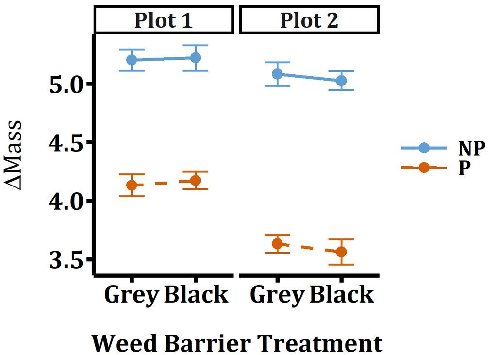

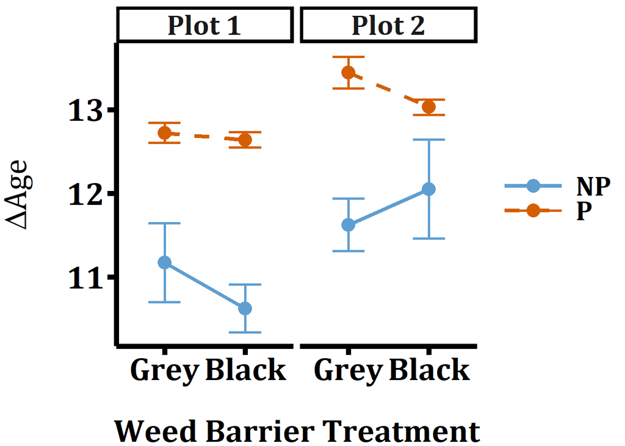

### Wasp survival

For wasp survival to eclosion, I am currently using a generalized linear mixed effects model on a subset of my data–using only wasps from hosts that I have dissected so that I have total load.

```r
#calculate total number died for binomial glm
ftm_pdis$tot_died <- ftm_pdis$load - ftm_pdis$num_ecl

#rescale load
ftm_pdis$resc_ld <- rescale(ftm_pdis$load, to=c(0,1))

wecl_surv_mod1 <- glmer(cbind(num_ecl, tot_died) ~ treat_heat * plot_id * resc_ld + (1|bug_id),
                      family = binomial,
                      data=ftm_pdis,
                      na.action = na.omit,
                      control=glmerControl(optimizer="bobyqa", optCtrl=list(maxfun=100000)))

anova(wecl_surv_mod1, test="F")
```

```
## Analysis of Variance Table
##                            Df Sum Sq Mean Sq F value
## treat_heat                  1 1.5384  1.5384  1.5384
## plot_id                     1 2.4404  2.4404  2.4404
## resc_ld                     1 5.3900  5.3900  5.3900
## treat_heat:plot_id          1 1.2572  1.2572  1.2572
## treat_heat:resc_ld          1 2.8328  2.8328  2.8328
## plot_id:resc_ld             1 0.1059  0.1059  0.1059
## treat_heat:plot_id:resc_ld  1 0.2227  0.2227  0.2227
```

```r
summary(wecl_surv_mod1)
```

```
## Generalized linear mixed model fit by maximum likelihood (Laplace
##   Approximation) [glmerMod]
##  Family: binomial  ( logit )
## Formula: cbind(num_ecl, tot_died) ~ treat_heat * plot_id * resc_ld + (1 |
##     bug_id)
##    Data: ftm_pdis
## Control: glmerControl(optimizer = "bobyqa", optCtrl = list(maxfun = 1e+05))
##
##      AIC      BIC   logLik deviance df.resid
##    379.1    394.8   -180.6    361.1       33
##
## Scaled residuals:
##      Min       1Q   Median       3Q      Max
## -1.23674 -0.05712  0.02721  0.07850  0.40565
##
## Random effects:
##  Groups Name        Variance Std.Dev.
##  bug_id (Intercept) 2.283    1.511
## Number of obs: 42, groups:  bug_id, 42
##
## Fixed effects:
##                                   Estimate Std. Error z value Pr(>|z|)
## (Intercept)                         -3.710      1.858  -1.997   0.0458 *
## treat_heaths                         4.315      2.047   2.108   0.0351 *
## plot_idplot2                         2.940      2.060   1.427   0.1535
## resc_ld                              3.403      4.082   0.834   0.4045
## treat_heaths:plot_idplot2           -3.361      2.319  -1.449   0.1473
## treat_heaths:resc_ld                -6.816      4.448  -1.532   0.1254
## plot_idplot2:resc_ld                -3.244      5.731  -0.566   0.5714
## treat_heaths:plot_idplot2:resc_ld    2.972      6.271   0.474   0.6356
## ---
## Signif. codes:  0 '***' 0.001 '**' 0.01 '*' 0.05 '.' 0.1 ' ' 1
##
## Correlation of Fixed Effects:
##             (Intr) trt_ht plt_d2 rsc_ld tr_:_2 trt_:_ pl_2:_
## treat_heths -0.906
## plot_idplt2 -0.899  0.815
## resc_ld     -0.946  0.857  0.851
## trt_hths:_2  0.798 -0.881 -0.888 -0.755
## trt_hths:r_  0.867 -0.937 -0.780 -0.917  0.826
## plt_dplt2:_  0.670 -0.608 -0.854 -0.710  0.758  0.651
## trt_ht:_2:_ -0.611  0.661  0.780  0.648 -0.834 -0.707 -0.914
```

I have not investigated this model in depth, as it is currently only running on a subset of my data. However, it seems that there may be an effect of weed barrier treatment (treat_heat), with the black weed barrier (treat_heaths) increasing wasp survival in comparison with the grey. This seems contradictory to what I see when I plot my data, but I have as yet not included sex in this model. See below for mean wasp survival of all treatments.

```
##   plot_id treat_heat    sex  N       ecl        sd       se        ci
## 1   plot1        con Female 19  6.157895  8.098444 1.857910  3.903325
## 2   plot1        con   Male 19 40.578947 33.885946 7.773969 16.332503
## 3   plot1         hs Female 31 10.064516 10.220683 1.835689  3.748977
## 4   plot1         hs   Male 31 35.000000 26.774366 4.808818  9.820917
## 5   plot2        con Female 24  9.666667 13.779842 2.812799  5.818717
## 6   plot2        con   Male 24 27.500000 21.455718 4.379630  9.059955
## 7   plot2         hs Female 30 10.433333 15.904203 2.903697  5.938727
## 8   plot2         hs   Male 30 25.900000 19.298651 3.523435  7.206235
```

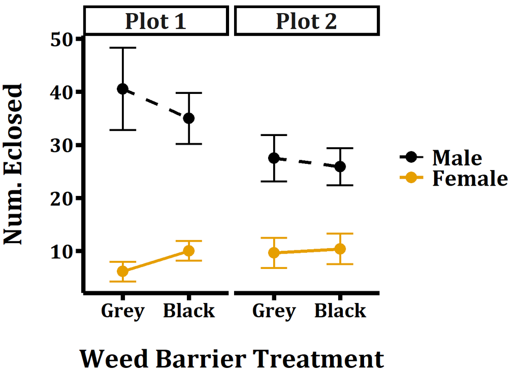

### Wasp adult mass:

```r
wadmass_mod1 <- lme(mass ~ treat_heat * plot_id * load * sex,
                    random = ~1|bug_id,
                    data = ftm_pl,
                    na.action = na.omit,
                    method = "ML")
anova(wadmass_mod1)
```

```
##                             numDF denDF   F-value p-value
## (Intercept)                     1    96 1825.3284  <.0001
## treat_heat                      1    96    0.2690  0.6052
## plot_id                         1    96    1.4292  0.2348
## load                            1    96    0.0544  0.8161
## sex                             1    69   62.4531  <.0001
## treat_heat:plot_id              1    96    0.5750  0.4501
## treat_heat:load                 1    96    0.7462  0.3898
## plot_id:load                    1    96    0.5857  0.4460
## treat_heat:sex                  1    69    3.6881  0.0589
## plot_id:sex                     1    69    0.0003  0.9855
## load:sex                        1    69    8.6279  0.0045
## treat_heat:plot_id:load         1    96    1.1092  0.2949
## treat_heat:plot_id:sex          1    69    0.1363  0.7132
## treat_heat:load:sex             1    69    2.3492  0.1299
## plot_id:load:sex                1    69    0.0238  0.8777
## treat_heat:plot_id:load:sex     1    69    0.0654  0.7989
```

```r
summary(wadmass_mod1)
```

```
## Linear mixed-effects model fit by maximum likelihood
##  Data: ftm_pl
##         AIC       BIC   logLik
##   -492.2663 -434.6934 264.1332
##
## Random effects:
##  Formula: ~1 | bug_id
##         (Intercept)   Residual
## StdDev:  0.04712279 0.03954333
##
## Fixed effects: mass ~ treat_heat * plot_id * load * sex
##                                              Value  Std.Error DF   t-value
## (Intercept)                             0.27785755 0.02932794 96  9.474159
## treat_heaths                            0.01203691 0.03886523 96  0.309709
## plot_idplot2                            0.00900318 0.04384345 96  0.205348
## load                                   -0.00024162 0.00021612 96 -1.118014
## sexMale                                -0.09129354 0.02713054 69 -3.364973
## treat_heaths:plot_idplot2               0.02129536 0.05559592 96  0.383038
## treat_heaths:load                       0.00018682 0.00028862 96  0.647279
## plot_idplot2:load                       0.00021423 0.00038477 96  0.556761
## treat_heaths:sexMale                    0.00713956 0.03616184 69  0.197434
## plot_idplot2:sexMale                    0.01437499 0.04105143 69  0.350170
## load:sexMale                            0.00051776 0.00019893 69  2.602702
## treat_heaths:plot_idplot2:load         -0.00046049 0.00046595 96 -0.988278
## treat_heaths:plot_idplot2:sexMale      -0.00700316 0.05206664 69 -0.134504
## treat_heaths:load:sexMale              -0.00035056 0.00026893 69 -1.303512
## plot_idplot2:load:sexMale              -0.00010641 0.00035677 69 -0.298268
## treat_heaths:plot_idplot2:load:sexMale  0.00011083 0.00043321 69  0.255821
##                                        p-value
## (Intercept)                             0.0000
## treat_heaths                            0.7575
## plot_idplot2                            0.8377
## load                                    0.2664
## sexMale                                 0.0013
## treat_heaths:plot_idplot2               0.7025
## treat_heaths:load                       0.5190
## plot_idplot2:load                       0.5790
## treat_heaths:sexMale                    0.8441
## plot_idplot2:sexMale                    0.7273
## load:sexMale                            0.0113
```

[output cut: 46 more lines]

```
## treat_heaths:sexMale
## plot_idplot2:sexMale
## load:sexMale
## treat_heaths:plot_idplot2:load         -0.244
## treat_heaths:plot_idplot2:sexMale      -0.437  0.525
## treat_heaths:load:sexMale              -0.740  0.369   0.594
## plot_idplot2:load:sexMale              -0.558  0.468   0.679   0.412
## treat_heaths:plot_idplot2:load:sexMale  0.459 -0.583  -0.855  -0.621 -0.824
##
## Standardized Within-Group Residuals:
##         Min          Q1         Med          Q3         Max
## -2.39830523 -0.38782846 -0.05541452  0.31727474  2.79095171
##
## Number of Observations: 181
## Number of Groups: 104
```

```
##   plot_id treat_heat    sex  N      mass         sd         se         ci
## 1   plot1        con Female 15 0.2559399 0.06827176 0.01762769 0.03780764
## 2   plot1        con   Male 19 0.2169102 0.05737709 0.01316321 0.02765487
## 3   plot1         hs Female 25 0.2878980 0.06327370 0.01265474 0.02611810
## 4   plot1         hs   Male 31 0.2192501 0.07183353 0.01290168 0.02634875
## 5   plot2        con Female 16 0.2739388 0.04879302 0.01219825 0.02599996
## 6   plot2        con   Male 24 0.2398904 0.06475097 0.01321724 0.02734193
## 7   plot2         hs Female 21 0.2907733 0.07439846 0.01623507 0.03386577
## 8   plot2         hs   Male 30 0.2316049 0.05563214 0.01015699 0.02077338
```

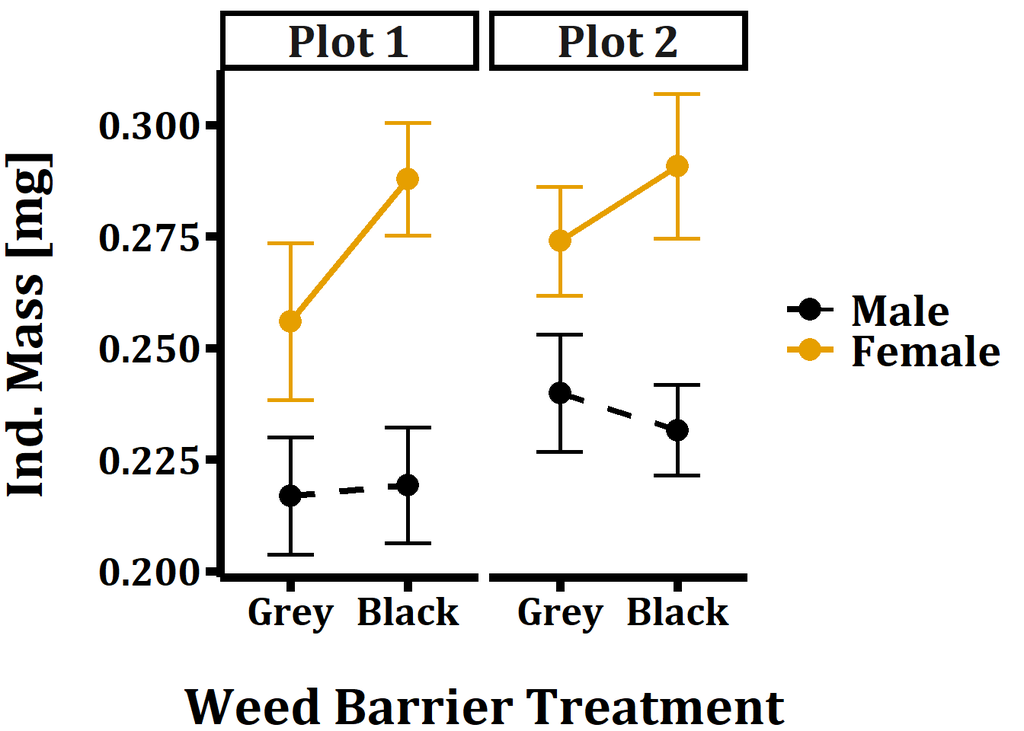

### Datalogger temperature data

I have conducted a few simple tests to examine whether my black weed barrier treatment increased the temperature of my field plots, and the caterpillars and plants in them. While it seems that there is a higher frequency of high temperatures in the black treatment, at least at midway up the plant, I will need to find more nuanced ways to examine the data to feel confident in these results.

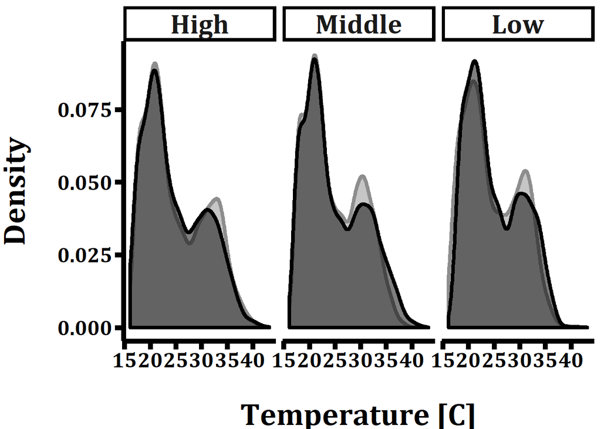

I have attempted to do this with a GAMM model (code included below, but not run due to length of processing), but need to make some adjustments. James suggested giving the GAMM a way to cycle over a 24 hours period, so the smoothing isn’t trying to average over day and night time temperatures across the whole dataframe. I have not attempted to do so yet, but it’s on the list of things to do.

```r
#per James suggestion, try a GAMM of temp data

dlt_tmp <- dlt_lng

#subset to only columns in model, and remove rows with NAs (so that predicted and fitted values can be
#added to the dataframe easily)
dlt_tmp <- select(dlt_tmp, tc, treat_hs, loc, date_time_j, temp)
dlt_tmp <- na.omit(dlt_tmp)


#make tc a factor so it will run as a random effect
dlt_tmp$tc <- factor(dlt_tmp$tc)

gam_temp_mod <- gam(temp ~ s(date_time_j, by=interaction(treat_hs, loc, bs="ts"))
                   + s(tc, bs="re") + treat_hs*loc,
                    method="ML", data=dlt_tmp, na.action = na.omit)
anova(gam_temp_mod)
summary(gam_temp_mod)
```

### Caterpillar location data

I have done some exploration of the behavioral location data I collected at each daily census. This data includes height on the plant (high, middle, low), leaf surface (upper, edge, under) and whether the caterpillar was in the sun or the shade. Due to the 3 dimensionality of this data, it has proven challenging to visualize and analyze. For now, I have mostly broken it down into separate components or pairs of components to try and see how the caterpillars are behaving on the plants. Some examples of my explorations can be see below.

I have plotted histograms of each location component separately, to see if caterpillars differ in their distribution on the plants by weed barrier treatment, parasitization treatment, or instar. I calculated the proportion of observations at each height (shown below), leaf surface and light (not shown), instead of counts, because there were differing numbers of observations depending on treatment and stage.

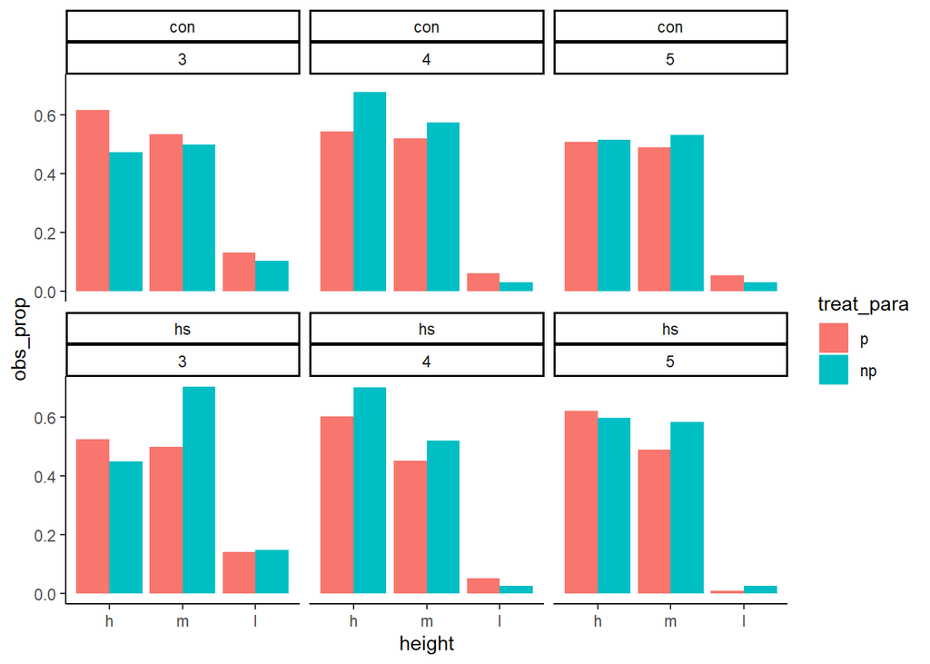

```r
#plotting proportion of observations of heigh by treat_heat, treat_para and stage
hstage_op_bar <- ggplot(hght_cnt, aes(x=height, y=obs_prop, fill=treat_para))
hstage_op_bar + geom_bar(stat="identity", position = "dodge"
)+facet_wrap(treat_heat~cen_stage)
```

On Joel’s suggestion, I also converted my location components to numeric values, and found the mean value for each treatment, stage, and rough time frame (am vs pm). I plotted location components against each other in various combinations to see if there were any obvious correlations. I provide an example of this below, with leaf surface plotted against height on plant for plot 1. Numbers closer to 0 on the X axis indicates caterpillars are lower on the plant, while larger numbers indicate higher location on the plant. On the Y axis, smaller numbers indicate the underside of a leaf, while larger numbers indicate the upper side.

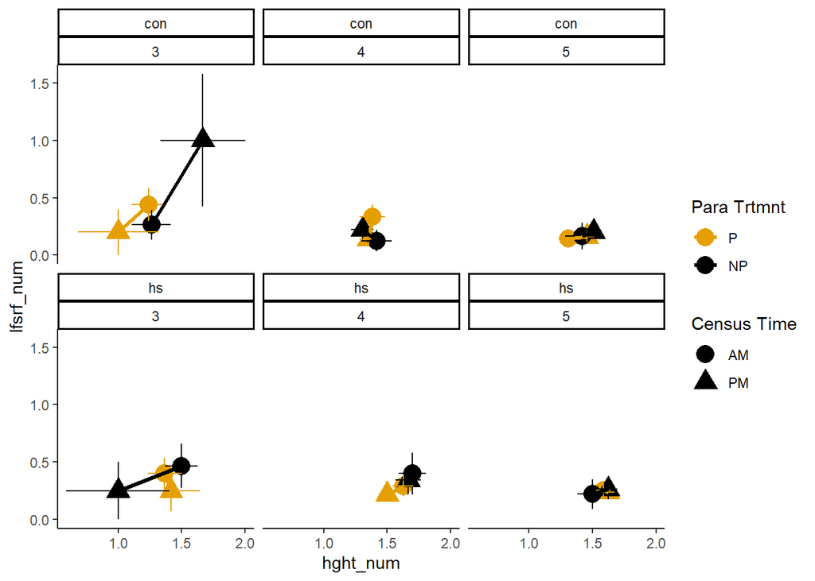

### Adding temperature data to census data

The most recent thing I have been working on with this data is attempting to combine the temperature data from the data logger with the census data I have for my caterpillars. I have a date and time stamp for each caterpillar census data point, as well as that caterpillar’s weed barrier treatment and where it was on the plant at each census. I should be able to take this data and match it up with the approprite temperature data taken from the thermoconductive models. However, this is proving to be challenging. The census time stamps do not match perfectly to the model time stamps, as the datalogger records the temperature only every 10 minutes. I have created an interval for each row in the datalogger dataframe, by adding the “end” time of each measurement (which is really the start of the next time step) by adding 10 minutes to each time stamp. My goal is to be able to match each census date/time stamp with the appropriate interval from the datalogger, and if the weed barrier treatment and plant height match for that census data point, extract the temperature and add it to the census dataframe. Below are some of my attempts to do this.

```r
#attempting to match temp data from datalogger with obs loc data

#load datalogger data:
dlt_lng <- read_csv("data/temp_data/Ms-Cc_FTM_datalogger_temp_ed_lng.csv")


#make a summary table of mean temp at each date_time stamp, by treat_hs and loc on plant
temp_sum <- summarySE(dlt_lng, measurevar = "temp",
                      groupvars = c("date_time_j", "treat_hs", "loc"),
                      na.rm = TRUE)


#rename loc values to be the same as height in ftm_lng
temp_sum$loc <- ifelse(temp_sum$loc=="h_un_sh", "h",
                       ifelse(temp_sum$loc=="m_un_sh", "m",
                              ifelse(temp_sum$loc=="l_un_sh", "l", "unk")))



#make a cen_date_time column for ftm_lng
ftm_lng$cen_time_dec <- ftm_lng$cen_time/24
ftm_lng$cen_date_time <- ftm_lng$cen_date + ftm_lng$cen_time_dec


#attempting to make a date_time_end column, so that I have 2 columns that create a range
  ##then I can hopefully match the cen_date_time to the range that has the temp when the census was taken
  ##could do this by trying to match the start date_time and add the next step in the sequence, but that
  ##seemed complicated to figure out. Instead, have just added the time interval (10 min = .007) to each
  ##step. This means every other step is off by .0001, because some are .0069 and some are .007. I don' think
  ##this will cause too many problems, though?

temp_sum$date_time_end <- temp_sum$date_time_j + .007


#attempting to match the cen_date time with the range of date_time_j and date_time_end, and pull that temp
  ##value from the data logger. Need to match location on plant and treat_heat too

test_dat <- ftm_lng
```

Some things that didn’t work at all:

```r
#attempting to use ifelse argument--doesn't work probably because the data frames are very different sizes
#did not work, unsurprisingly
test_dat$temp <- ifelse(test_dat$cen_date_time >= temp_sum$date_time_end
                        & test_dat$cen_date_time <= temp_sum$date_time_j
                        & test_dat$treat_heat == temp_sum$treat_hs
                        & test_dat$height == temp_sum$loc, temp_sum$temp, 0)


#trying with fuzzy_join function--sort of worked, but dulicated rows a ton

#pare down temp_sum to only columns needed
temp_sum_sel <- select(temp_sum, date_time_j, date_time_end, treat_hs, loc, temp)

fuzzy_left_join(X, Y[-1], by = c("number" = "number1", "number" = "number2"),
                match_fun  =list(`>=`, `<=`)) %>%
  mutate(found = c(NA, "YES")[(!is.na(number1)) + 1]) %>%
  select(names(X))


test_dat2 <- fuzzy_left_join(test_dat, temp_sum_sel,
                             by=c("cen_date_time" = "date_time_j", "cen_date_time" = "date_time_end"),
                             match_fun=list(`>=`, `<=`))
```

First thing that has sort of worked–a function that at least runs and seems to be able to at least partially match the date/time stamp of the census data to the date/time interval of the datalogger data. (Not run because it takes quite a long time)

```r
#Only thing that has worked, but it only returns a binary match response (0,1), but no info about which
  ##row matches what
  ##adapted from: https://stackoverflow.com/questions/53307707/compare-multiple-columns-in-2-different-dataframes-in-r

#temp1.df$new_mpg<-apply(temp1.df, 1, function(x) {
 # temp<-temp2.df[temp2.df$Cyl==x[],]
  #ifelse(any(apply(temp, 1, function(y) {
   # dplyr::between(as.numeric(x[1]),as.numeric(y[2]),as.numeric(y[3]))
#  })),1,0)
#})


test_dat$match <- apply(test_dat, 1, function(x){
  treat <- temp_sum[temp_sum$treat_hs==x[7],]
  ifelse(any(apply(treat, 1, function(y){
    dplyr::between(as.numeric(x[198]), as.numeric(y[1]), as.numeric(y[9]))
  })), 1, 0)
})
```

Probably my next steps are trying some other approaches to attach the temperature data to my census data, so that I can more directly test if caterpillar location differs in with temperature. This will also allow me to investigate whether caterpillars in different treatments (weed barrier, parasitization) had different behavioral responses to temperature. Joel suggested writing a model with a linear spline that could predict the temperaure for each minute between the 10 minute intervals of the datalogger. Then I could directly match the census data to the predicted temperature from the model. This might be my next approach when I return to these analyses next semester.